# Demographic effects on Crime

### Gender

So, we trying a few more things with the assumption to look at male/female ratio in the U.S. states and how that might impact rape rates. Assumption: more males equals more prospective rapists

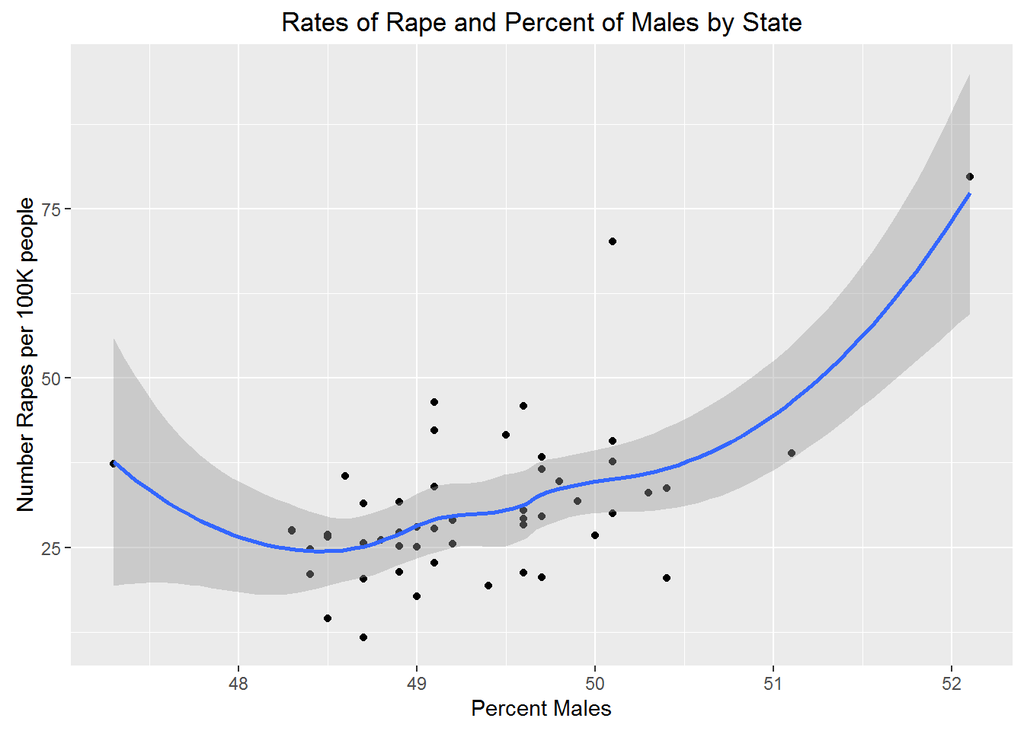

```r
# Percent of males -

# smoothed version - seems to show modest rise with more education!
stcrime %>% ggplot(aes(x= pct_male, y = rape_pct)) +
geom_point() + labs(title = "Rates of Rape and Percent of Males by State", y = "Number Rapes per 100K people", x = "Percent Males") + geom_smooth()
```

We don’t really see much trend here as most states have similar male/female ratios; however we do see that a few states that do have more then 50% male population the rape rate significantly increases. But since thats only a couple of cases where the population of males is high we cannot make any conclusions here.

In this scenerio, we are going to dive a bit deeper; we are going to look to see if having more younger males in a state have any impact on rape. The next few graphs will focus on younger male ratios in a state and its effects on rape rates.

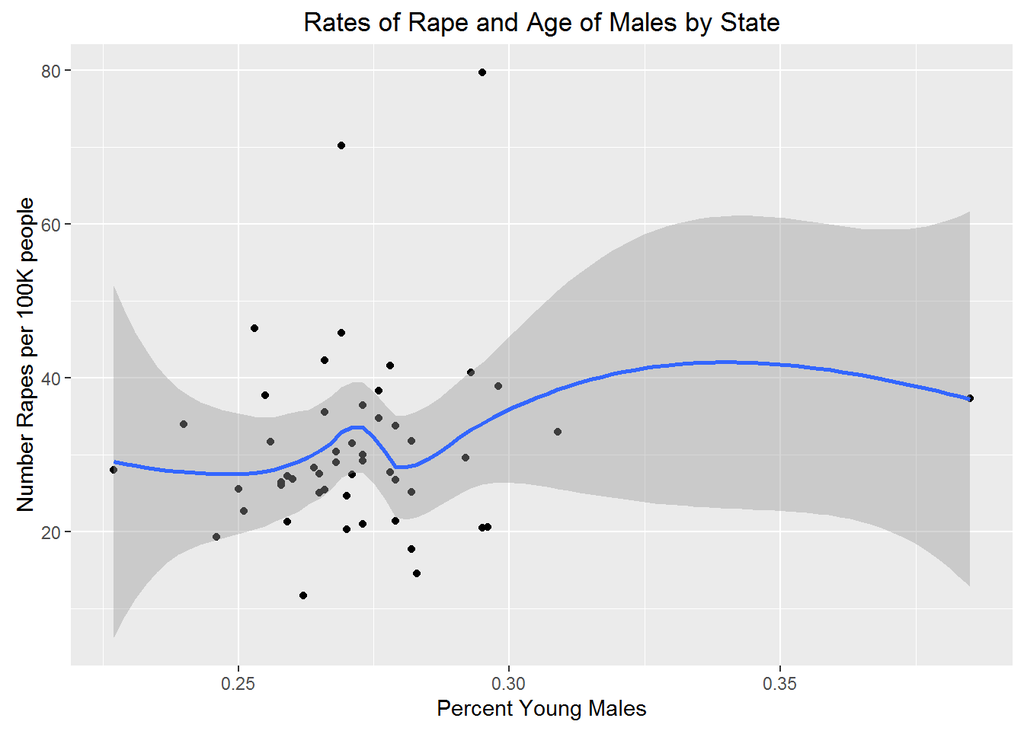

```r
# Young Males - younger age group may be more inclined

# smoothed version
stcrime %>% ggplot(aes(x= pct_young_male, y = rape_pct)) +
geom_point() + labs(title = "Rates of Rape and Age of Males by State", y = "Number Rapes per 100K people", x = "Percent Young Males") + geom_smooth()
```

Again we could not find much correlations except that most states have between 25-30% young males.

In general relating to males, perhaps the following seemed to have some correlation:

Percent of males - More males in general seems correlated with higher incidence of rape.

### Race

We will now look at Race and its impacts on Rape. More specifically we will look at racial mix using % white as proxy

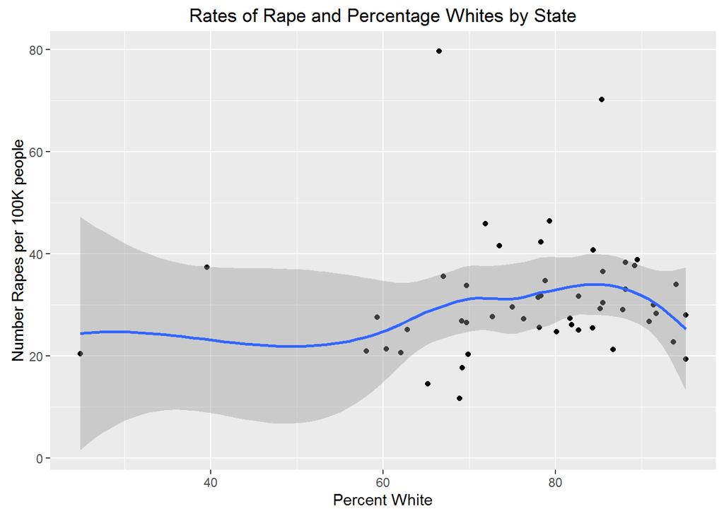

```r
# smoothed version
stcrime %>% ggplot(aes(x= pct_white, y = rape_pct)) +
geom_point() + labs(title = "Rates of Rape and Percentage Whites by State", y = "Number Rapes per 100K people", x = "Percent White") + geom_smooth()
```

### Population Density

Population density - larger, more open spaces with less oversight will cause more rapes or less dense spaces will be a contributing factor to rape. Lets see:

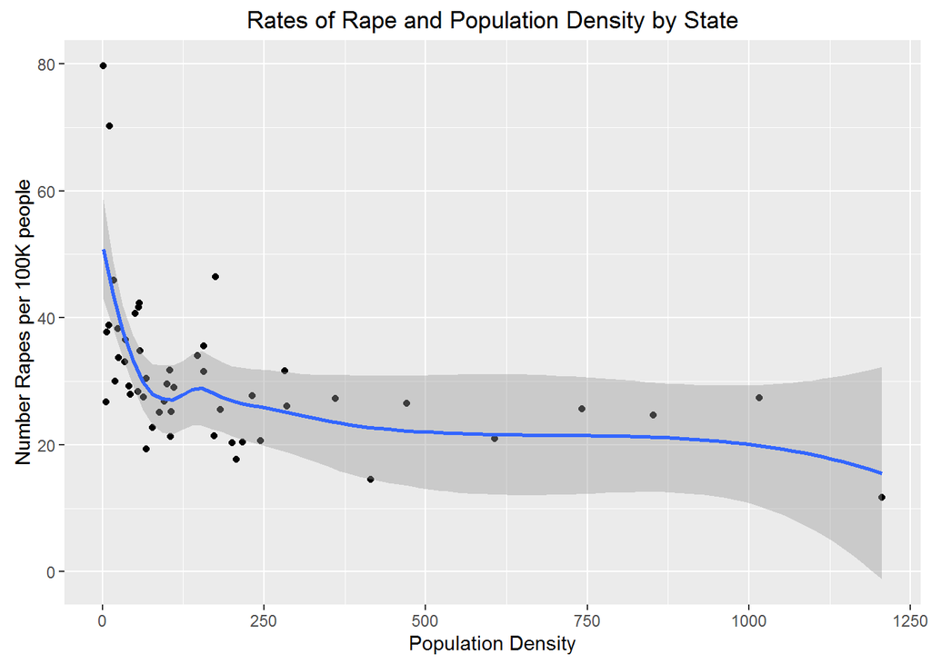

```r
#smoothed version
stcrime_lessDC <- stcrime %>% filter(State != "District of Columbia")
stcrime_lessDC %>% ggplot(aes(x= pop_density, y = rape_pct)) +
geom_point() + labs(title = "Rates of Rape and Population Density by State", y = "Number Rapes per 100K people", x = "Population Density") + geom_smooth()
```

A trend can definitely be seen here, he lower the population density the higher the rape rate.

Lets focus on the lower end of pop density to take a closer look at it

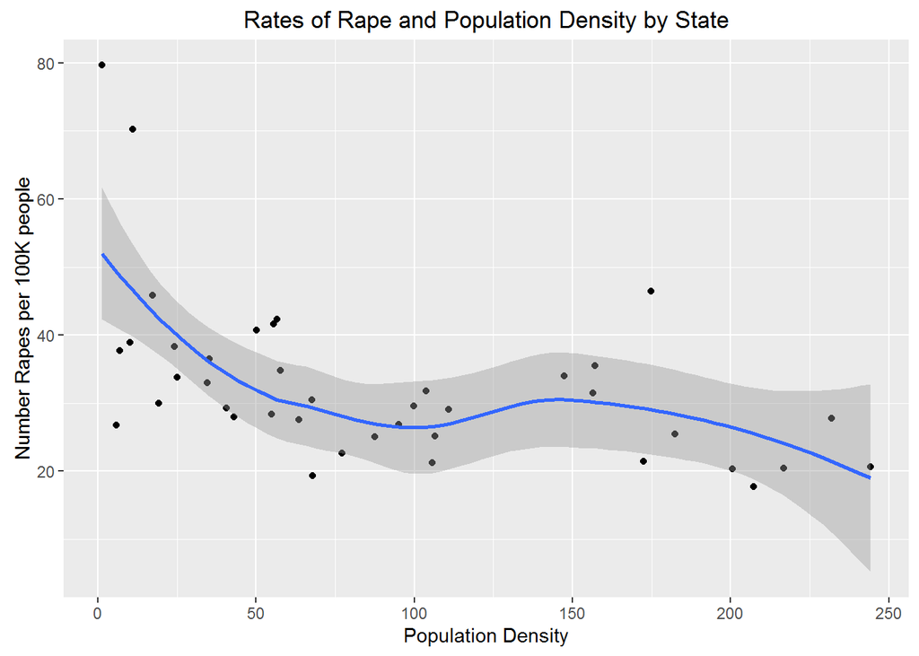

```r
# smooth version focusing on the lower end of pop density
stcrime_lessDC %>% filter(pop_density <= 250) %>% ggplot(aes(x= pop_density, y = rape_pct)) + geom_point() + labs(title = "Rates of Rape and Population Density by State", y = "Number Rapes per 100K people", x = "Population Density") + geom_smooth()
```

Population Density - it does seem as if at least in states where the population density is less than 100 people per square mile there is a significantly higher incidence of rape

Let’s look in more depth at the worst and best four states and the impacts of median age, population density and male ratios.

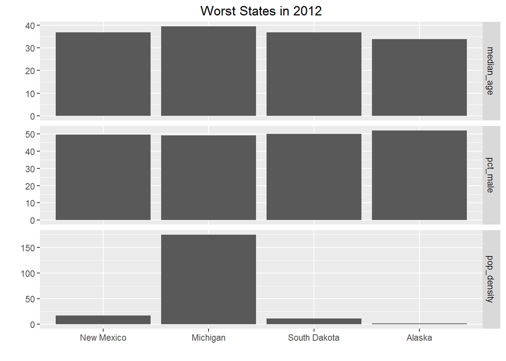

```r
worst <- stcrime %>% filter(State %in% c("Alaska","South Dakota","Michigan","New Mexico")) %>% select(State,pct_male,pop_density,median_age)
worst$pct_male <- as.numeric(as.character(worst$pct_male))

# Collect this for later
wsum <- worst %>% summarise(mean(pct_male), mean(pop_density), mean(median_age))

# Transform for facets
worst <- worst %>% gather(key = variable, Value = pct_male:median_age)

# Other ways to do it
#ggplot(worst, aes(x=State, y=value)) + geom_bar(stat='identity') + facet_grid(.~variable, scales = "free") +coord_flip() + labs(x='',y='')

#ggplot(worst,aes(x=State, y=value)) + geom_bar(stat='identity') + facet_grid(variable~., scales = "free") +coord_flip() + labs(x='',y='')

ggplot(worst,aes(x=State, y=value)) + geom_bar(stat='identity') + facet_grid(variable~., scales = "free") + labs(title = "Worst States in 2012", x='',y='')
```

And here are the four states with the best percentage, compared.

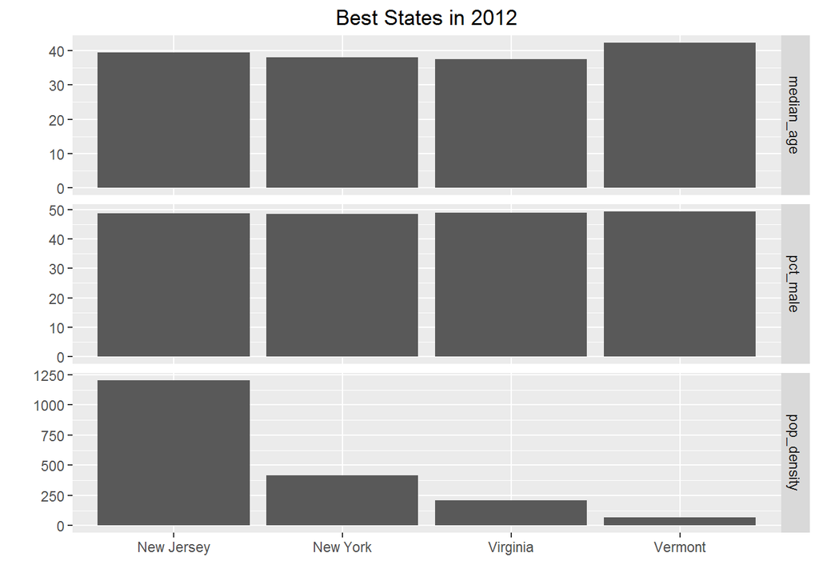

```r
best <- stcrime %>% filter(State %in% c("New Jersey","New York","Virginia","Vermont")) %>% select(State,pct_male,pop_density,median_age)
best$pct_male <- as.numeric(as.character(best$pct_male))

# Collect for later
bsum <- best %>% summarise(mean(pct_male), mean(pop_density), mean(median_age))

# Transform for facets
best <- best %>% gather(key = variable, Value = pct_male:median_age)

ggplot(best,aes(x=State, y=value)) + geom_bar(stat='identity') + facet_grid(variable~., scales = "free")  + labs(title = "Best States in 2012", x='',y='')
```

So, there are some possible indicators viewed this way. Racial mix, in the end seems, unlikely. However, larger, less policed areas with less people may be a contributing factor, and a greater percentage of males may increase the odds of one being prone to misconduct. A perhaps quick way to summarize them is below.

```r
# make a table of averages
s <- c("Worst","Best")
sumt <- rbind(wsum,bsum)
sum <- data.frame(s,sumt)
kable(sum)
```

| s | mean.pct_male. | mean.pop_density. | mean.median_age. |
| --- | --- | --- | --- |
| Worst | 50.225 | 51.075 | 36.70 |
| Best | 48.900 | 473.950 | 39.35 |